# AE-1.3 Modelos de Regresión Espacial y Machine Learning

Paloma Quiroz A01620449 | Sandra Sotelo A01625347 | Adriana Delgado A01246093 | Lizbeth Martínez A01383976

26/4/2023

```r
library(dplyr)
library(magrittr)
library(maptools)
library(sf)
library(tmap)
library(spdep)
library(rgdal)
library(tidyverse)
library(tigris)
library(mapview)
library(GWmodel)
library(regclass)
library(viridis)
library(grid)
library(dlookr)
library(tmap)
```

# Objetivo general

A partir de diversas bases de datos relevantes sobre factores influyentes en los casos de COVID-19 a nivel municipal, este análisis busca identificar los factores más significativos en el aumento o disminución de la enfermedad. También se analizarán los clusters de casos confirmados y su relación espacial con la enfermedad. Además, se explorará la construcción de un modelo de regresión espacial para predecir la tasa de casos de COVID-19 por municipio en función de la ubicación y la cercanía a otros municipios.

## Describir 3-5 diferencias entre la estimación de modelo de regresión global y la estimación del método de Geographic Weighted Regression (GWR).

La regresión global (regresión lineal múltiple) asume que la relación entre la variable dependiente y las variables independientes es constante en todo el espacio, es decir, que los coeficientes de regresión son iguales para todas las observaciones.

Por otro lado, la regresión GWR (Geographically Weighted Regression) es una técnica de modelización espacial que permite explorar la variación de las relaciones entre variables a lo largo del espacio. En este modelo, los coeficientes de regresión varían en función de la ubicación espacial de la observación, lo que la hace especialmente útil cuando se sospecha que la relación entre la variable dependiente y las variables independientes es espacialmente heterogénea. En caso contrario, una regresión global sería la mejor opción, ya que asume que todas las regiones tienen el mismo comportamiento.

La principal diferencia entre la regresión global y la regresión GWR es que esta última tiene en cuenta la variabilidad espacial de los datos y permite explorar cómo la relación entre las variables cambia según la ubicación en el espacio. Mientras que la regresión global es útil para explorar la relación entre variables, no puede capturar la heterogeneidad espacial de los datos.

En la regresión global se ajusta una línea de regresión para todo el conjunto de datos, mientras que en la regresión GWR se ajusta una superficie de respuesta localmente en cada ubicación. Esto se ve reflejado en los coeficientes: mientras la regresión global estima un conjunto de coeficientes fijos que se aplican a todo el conjunto de datos (Estimate), la regresión GWR estima un conjunto de coeficientes variables que se aplican solo a las observaciones en una vecindad local de cada ubicación (Min., 1st Qu., Median, 3rd Qu., Max., Global).

Ahora bien, comenzaremos con la exploración de nuestros datos:

```r
#Establecemos nuestro directorio de trabajo
#getwd()
#file.choose()
setwd("C:\\Users\\Paloma Quiroz\\OneDrive - Instituto Tecnologico y de Estudios Superiores de Monterrey\\Planeación Estratégica 8\\M1")
```

[output not shown]

[output cut: 22 more lines]

```
##  Max.   :56.04    Max.   :31.67   Max.   :98230.5   Max.   :4698.00
##    entidad             region             densidad       tasa_confirmados_pob
##  Length:2437        Length:2437        Min.   :   95.0   Min.   :   0.00
##  Class :character   Class :character   1st Qu.:  707.4   1st Qu.:  24.42
##  Mode  :character   Mode  :character   Median : 1125.4   Median :  59.73
##                                        Mean   : 1790.5   Mean   :  89.91
##                                        3rd Qu.: 1997.2   3rd Qu.: 118.73
##                                        Max.   :22658.5   Max.   :1151.25
##  tasa_confirmados_km
##  Min.   :   0.0000
##  1st Qu.:   0.0606
##  Median :   0.2481
##  Mean   :   8.0781
##  3rd Qu.:   1.0931
##  Max.   :1136.9697
```

```r
#Leemos nuestra base con datos espaciales y la combinamos con nuestra base de datos de municipios.
mx_shp <- readOGR(dsn = "shp_mx_mpios/mx_mpios.shp") ### geospatial data. It has 254 features meaning 254 polygons (counties).
mx_geodata <- geo_join(mx_shp, df, 'IDUNICO', 'IDUNICO', how = 'inner') ### Combining geospatial and non-spatial data
names(mx_geodata)
```

```
##  [1] "CODELAG"                        "CVE_ENT"
##  [3] "IDUNICO"                        "IDUNICO.1"
##  [5] "mpio"                           "poblacion_2022"
##  [7] "hogrem2015"                     "hogremjefmuj2015"
##  [9] "popnoafmed2015"                 "gini2015"
## [11] "popden2020"                     "crimen_2018"
## [13] "crimen_2019"                    "inclusion_fin_2019"
## [15] "porcentaje_pob_pobreza"         "porcentaje_pob_pobreza_ext"
## [17] "porcentaje_pob_servicios_salud" "porcentaje_pob_acceso_ss"
## [19] "pob_6.14_no_edu"                "rezago_social"
## [21] "grado_rs"                       "extension_km2"
## [23] "population2020"                 "populationm2020"
## [25] "populationw2020"                "socialgapindex"
## [27] "socialgapindex_scale"           "covid2020"
## [29] "covid_rate_2020"                "covid2021"
## [31] "covid_rate_2021"                "pop_obesity"
## [33] "pop_hypertension"               "pop_diabetes"
## [35] "total_confirmados"              "No_hospitales"
## [37] "entidad"                        "region"
## [39] "densidad"                       "tasa_confirmados_pob"
## [41] "tasa_confirmados_km"
```

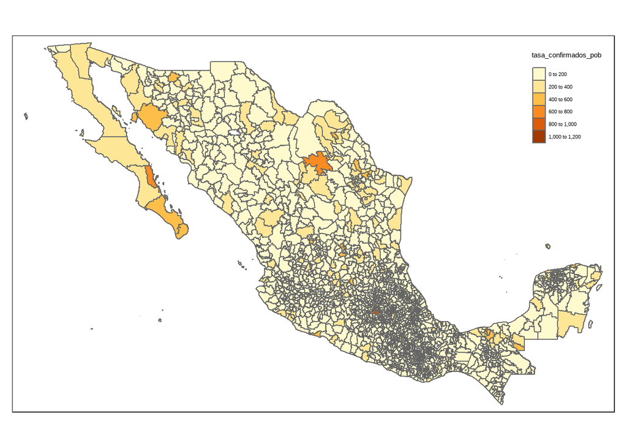

```r
### visualzing Tasa de confirmados por 10,000 habitantes
qtm(mx_geodata, "tasa_confirmados_pob")
```

```r
#mapview(mx_geodata, zcol = "tasa_confirmados_pob")
```

A continuación enfocamos el mapa para mostrar el comportamiento de los municipios de Ciudad de México con detalle respecto a la tasa de confirmados por cada 10,000 habitantes. Es evidente que la zona de Álvaro Obregón es la más grave, tal vez del país, pues acumula entre 1,100 y 1,200 confirmados de COVID-19 por cada 10,000 habitantes. Habrá que explorar las caracterísiticas de su población para saber si estas influyen en su comportamiento.

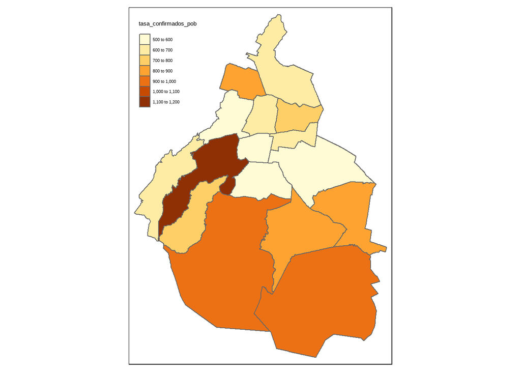

```r
mx_cdmx_geodata <- subset(mx_geodata, entidad == 'Ciudad de M<e9>xico')
qtm(mx_cdmx_geodata, "tasa_confirmados_pob")
```

```r
#mapview(mx_cdmx_geodata, zcol = "tasa_confirmados_pob")
```

## Especificar 2 matrices de conectividad considerando enfoque de contiguedad (queen / rook), vecino más próximo (k nearest neighbor – knn), y / o distancia

La creación de una matriz de conectividad nos permitirá evaluar la conexión entre los diferentes municipios de nuestra base de datos. Se ha realizado una matriz de conectividad utilizando las técnicas de Queen y Rook para determinar cuál es la más adecuada para la construcción posterior de nuestro modelo. En general, la técnica de Queen considera conexiones cuando dos unidades comparten al menos un vértice, mientras que la técnica de Rook lo considera solo cuando las unidades comparten un lado completo.

#### Matríz de conectividad usando Queen

```r
# Vamos a verificar que solo estemos utilizando los datos que se encuentran en nuestra base de datos de municipios
IDSS <- mx_geodata$IDUNICO
mx_shp <- subset(mx_shp, IDUNICO %in% IDSS)
### modelling spatial negihbors and spatial connectivity matrices with Queen
swm_queen <- poly2nb(mx_shp, queen = TRUE)
summary(swm_queen)
```

```
## Neighbour list object:
## Number of regions: 2437
## Number of nonzero links: 14204
## Percentage nonzero weights: 0.2391661
## Average number of links: 5.828478
## Link number distribution:
##
##   1   2   3   4   5   6   7   8   9  10  11  12  13  14  15  16  17  20  21  22
##   8  64 210 397 504 456 320 229 139  51  26  13   4   4   3   3   2   1   2   1
## 8 least connected regions:
## 299 354 667 858 930 1243 1461 2234 with 1 link
## 1 most connected region:
## 1173 with 22 links
```

```r
### summary of spatial weight matrix
# There are 2437 area units / counties in Texas
# Most connected area unit has 22 neighbours
# Least connected areea unit has 1 neighbor
```

La distribución de conexiones muestra que hay una gran cantidad de regiones con pocas conexiones y relativamente pocas regiones con muchas conexiones. Se han identificado las ocho regiones con el menor número de conexiones, las cuales están aisladas de las demás regiones, cada una con una sola conexión. Por otro lado, la región 1173 tiene el mayor número de conexiones (22), lo que sugiere que está altamente conectada con muchas otras regiones en el conjunto de datos.

En resumen, los resultados indican que hay una amplia variación en la conectividad, con algunas regiones altamente conectadas y otras aisladas. Esto puede tener implicaciones en el análisis espacial y la identificación de patrones geográficos en los datos, ya que las regiones aisladas pueden tener características distintas a las regiones altamente conectadas.

En la parte inferior se presenta una representación gráfica de esta matriz de conectividad.

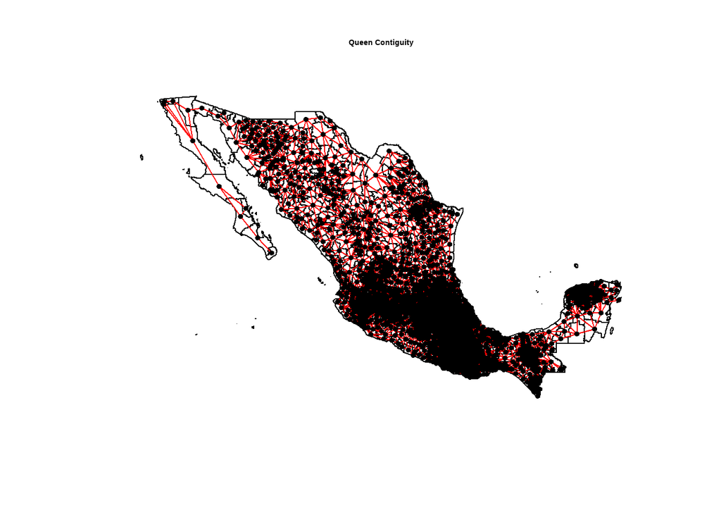

```r
### plotting queen contiguity based neighbors maps
plot(mx_shp, borders = 'lightgrey')
plot(swm_queen, coordinates(mx_shp), pch = 19, cex = 0.6, add = TRUE, col = "red")
title(main = "Queen Contiguity", cex.main = 0.9)
```

#### Matríz de conectividad usando Rook

```r
swm_rook <- poly2nb(mx_shp, queen = FALSE)
summary(swm_rook)
```

```
## Neighbour list object:
## Number of regions: 2437
## Number of nonzero links: 13992
## Percentage nonzero weights: 0.2355964
## Average number of links: 5.741485
## Link number distribution:
##
##   1   2   3   4   5   6   7   8   9  10  11  12  13  14  15  16  17  19  20  21
##   8  70 223 420 499 449 321 225 117  53  20  12   5   4   4   1   2   1   1   2
## 8 least connected regions:
## 299 354 667 858 930 1243 1461 2234 with 1 link
## 2 most connected regions:
## 1058 1173 with 21 links
```

La distribución del número de conexiones muestra que hay ocho regiones con el menor número de conexiones, cada una con solo una conexión, lo que significa que están aisladas de las demás regiones. Las dos regiones más conectadas son la región 1058 y la región 1173, cada una con 21 conexiones.

Estos resultados sugieren que hay una variación en la conectividad entre las regiones, con algunas regiones altamente conectadas y otras aisladas. Esta variación puede tener implicaciones en el análisis espacial y la identificación de patrones geográficos en los datos.

En la parte inferior observamos la matriz de conectividad Rook de una manera gráfica.

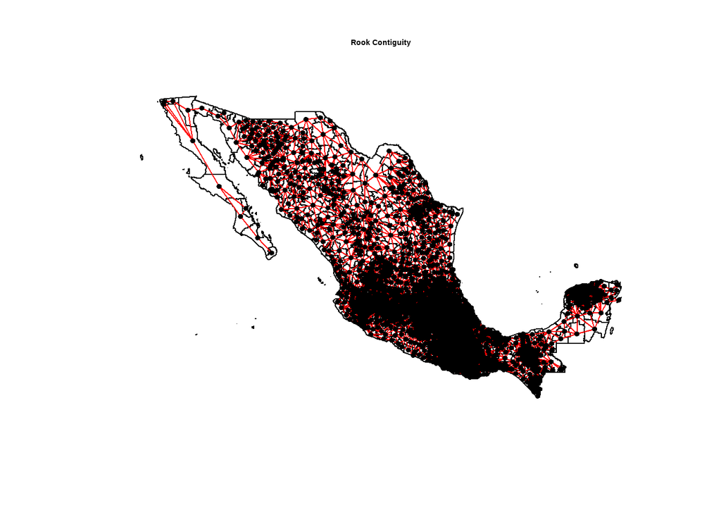

```r
### plotting rook contiguity based neighbors maps
plot(mx_shp, borders = 'lightgrey')
plot(swm_rook, coordinates(mx_shp), pch = 19, cex = 0.6, add = TRUE, col = "red")
title(main = "Rook Contiguity", cex.main = 0.9)
```

#### Distancia en los vecindarios cercanos

Para calcular la distancia entre vecinos, extrajimos las coordenadas de cada municipio.

```r
### computing distance based neighbours
coords <- coordinates(mx_shp)
head(coords)
```

```
##        [,1]     [,2]
## 0 -99.20622 19.19834
## 1 -99.09036 19.24515
## 2 -99.26841 19.26898
## 3 -99.18211 19.48533
## 4 -99.16113 19.38064
## 5 -99.14906 19.43137
```

Ahora vamos a evaluar las estadisticas generales de distancias entre vecinos.

```r
knn1 <- knn2nb(knearneigh(coords))
knn1_dist <- unlist(nbdists(knn1, coords, longlat = TRUE))
summary(knn1_dist)
```

```
##    Min. 1st Qu.  Median    Mean 3rd Qu.    Max.
##   0.558   7.479  11.449  15.878  19.143 229.364
```

```r
### Based on knn_distance we can consider that the summary shows that the largest first nearest neighbour distance is 229.364 km, so using this as the upper band / threshold gives certainty that all units will have at least 1 neighbour because it’s the max distance.
```

En la parte superior hay un resumen de las distancias entre los puntos mas cercanos, utiliza la matriz de vecinos calculada en el paso anterior. La distancia mínima entre vacinos es de 0.5 km y la distancia maxima es de 229.3 km; en promedio la distancia entre municipios vecinos es de 15.8 km. La mediana de las distancias entre vecinos es de 11.4 km, lo que significa que el 50% de las distancias entre vecinos son menores o iguales a 11.4 km.

```r
dwm <- dnearneigh(coords, 0 ,100, longlat = TRUE)
dwm # On average, each location is nearest in distance to another 121.6621 point areas?
```

```
## Neighbour list object:
## Number of regions: 2437
## Number of nonzero links: 302426
## Percentage nonzero weights: 5.092231
## Average number of links: 124.0977
## 5 regions with no links:
## 348 352 353 355 2429
```

Ahora, para obtener la lista de nearest neighbors, vamos a definir un parametro de las distancias máximas y mínimas para considerarse vecinos, en este caso vamos a especificar que son 100 km, considerando esto, se indica que esta lista contiene información sobre 2,437 regiones y 302,426 enlaces no nulos entre ellas, lo que representa un 5.09% de enlaces no nulos en relación al total de posibles enlaces. Además, se señala que en promedio cada región está conectada a 124.0977 otras regiones. Por último, se menciona que hay 5 regiones que no tienen ningún enlace y se identifican por sus números de identificación: 348, 352, 353, 355 y 2429.

A continuación se observa gráficamente lo descrito.

[figure not shown]

```r
plot(mx_shp, border = "lightgrey")
plot(dwm, coords, add = TRUE, pch = 19, cex = 0.6)
title(main = "Neighbours within 229 km", cex.main = 0.9)
```

## Elaborar ESDA a partir del rezago espacial de 3-5 variables. Identificar la posible presencia de autocorrelación espacial en las variables seleccionadas

Para crear nuestro análisis espacial, vamos a crear una matriz Queen y un spacial lag de nuestra variable de interés.

```r
rswm_queen <- nb2listw(swm_queen, style = "W", zero.policy = TRUE)
rswm_queen
```

```
## Characteristics of weights list object:
## Neighbour list object:
## Number of regions: 2437
## Number of nonzero links: 14204
## Percentage nonzero weights: 0.2391661
## Average number of links: 5.828478
##
## Weights style: W
## Weights constants summary:
##      n      nn   S0       S1       S2
## W 2437 5938969 2437 897.0276 10255.89
```

```r
### lets create a spatial lag of dataset's variable
mx_geodata$sp_tasa_confirmados_pob <- lag.listw(rswm_queen, mx_geodata$tasa_confirmados_pob, zero.policy=TRUE)
# texas_geodata$sp_median_household_income
```

Aquí observamos dos gráficas de nuestra variable de interés, la tasa de confirmados de COVID-19, una con la variable en su forma original y la otra mostrando el rezago espacial:

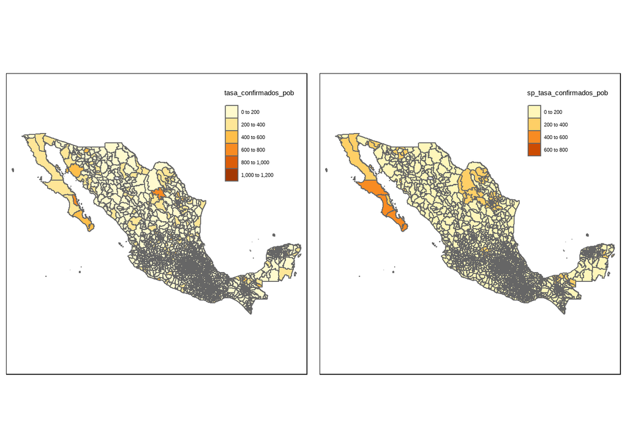

```r
tasa_confirmados_pob <- qtm(mx_geodata, "tasa_confirmados_pob")
spatial_lag_tasa_confirmados_pob <- qtm(mx_geodata, "sp_tasa_confirmados_pob")
tmap_arrange(tasa_confirmados_pob, spatial_lag_tasa_confirmados_pob, asp = 1, ncol =2)
```

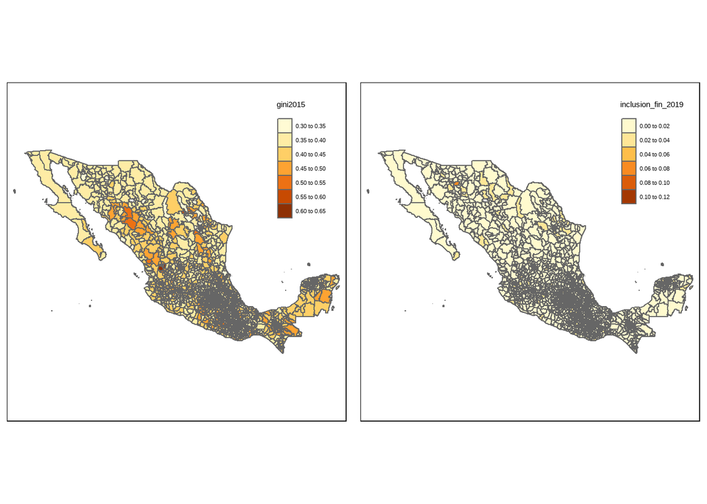

```r
gini2015 <- qtm(mx_geodata, "gini2015")
inclusion_fin_2019 <- qtm(mx_geodata, "inclusion_fin_2019")
tmap_arrange(gini2015, inclusion_fin_2019, asp = 1, ncol =2)
```

Al analizar la tasa de hospitales en nuestro país, se observa que la mayoría de los municipios tienen una cantidad limitada de instalaciones hospitalarias, oscilando entre 0 y 40 hospitales por cada 10,000 habitantes. Este panorama evidencia la escasa infraestructura hospitalaria disponible en el territorio nacional, lo cual tiene un impacto significativo en la tasa de confirmados de COVID-19.

Por otra parte, al evaluar el porcentaje de la sociedad con acceso a servicios de seguridad social, se identifica que la mayoría de los municipios se ubican en una escala que oscila entre el 60% y el 100%. Este resultado indica que la mayor parte de la población cuenta con algún tipo de protección social, lo cual es un indicador positivo:

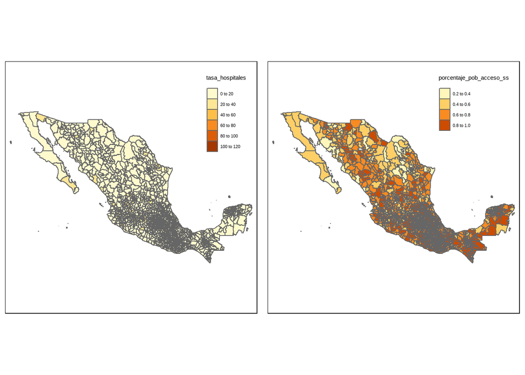

```r
mx_geodata$tasa_hospitales <- (mx_geodata$No_hospitales / mx_geodata$poblacion_2022) * 10000
tasa_hospitales <- qtm(mx_geodata, "tasa_hospitales")
porcentaje_pob_acceso_ss <- qtm(mx_geodata, "porcentaje_pob_acceso_ss")
tmap_arrange(tasa_hospitales, porcentaje_pob_acceso_ss, asp = 1, ncol =2)
```

En cuanto a la población con diabetes e hipertensión, vemos una distribución más uniforme alrededor de todo el pais:

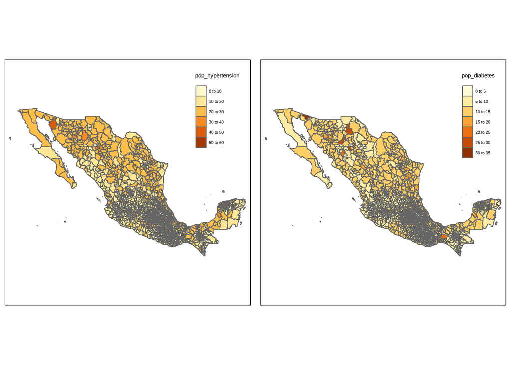

```r
pop_hypertension <- qtm(mx_geodata, "pop_hypertension")
pop_diabetes <- qtm(mx_geodata, "pop_diabetes")
tmap_arrange(pop_hypertension, pop_diabetes, asp = 1, ncol =2)
```

Ahora vamos a medir la autocorrelación espacial de nuestras variables de interés para asegurar la significancia de nuestros modelos:

```r
### identifying and measuring spatial autocorrelation

# Moran's I Test
moran.test(mx_geodata$tasa_confirmados_pob, listw = rswm_queen, zero.policy = TRUE, na.action = na.omit)
```

```
##
##  Moran I test under randomisation
##
## data:  mx_geodata$tasa_confirmados_pob
## weights: rswm_queen
##
## Moran I statistic standard deviate = 45.989, p-value < 2.2e-16
## alternative hypothesis: greater
## sample estimates:
## Moran I statistic       Expectation          Variance
##      0.5620811862     -0.0004105090      0.0001495982
```

```r
moran.test(mx_geodata$gini2015, listw = rswm_queen, zero.policy = TRUE, na.action = na.omit)
```

```
##
##  Moran I test under randomisation
##
## data:  mx_geodata$gini2015
## weights: rswm_queen
##
## Moran I statistic standard deviate = 24.129, p-value < 2.2e-16
## alternative hypothesis: greater
## sample estimates:
## Moran I statistic       Expectation          Variance
##      0.2955467183     -0.0004105090      0.0001504508
```

```r
moran.test(mx_geodata$inclusion_fin_2019, listw = rswm_queen, zero.policy = TRUE, na.action = na.omit)
```

```
##
##  Moran I test under randomisation
##
## data:  mx_geodata$inclusion_fin_2019
## weights: rswm_queen
##
## Moran I statistic standard deviate = 15.944, p-value < 2.2e-16
## alternative hypothesis: greater
## sample estimates:
## Moran I statistic       Expectation          Variance
##      0.1946309339     -0.0004105090      0.0001496389
```

```r
moran.test(mx_geodata$tasa_hospitales, listw = rswm_queen, zero.policy = TRUE, na.action = na.omit)
```

```
##
##  Moran I test under randomisation
##
## data:  mx_geodata$tasa_hospitales
## weights: rswm_queen
##
## Moran I statistic standard deviate = 22.126, p-value < 2.2e-16
## alternative hypothesis: greater
## sample estimates:
## Moran I statistic       Expectation          Variance
##      0.2704225182     -0.0004105090      0.0001498359
```

```r
moran.test(mx_geodata$porcentaje_pob_acceso_ss, listw = rswm_queen, zero.policy = TRUE, na.action = na.omit)
```

```
##
##  Moran I test under randomisation
##
## data:  mx_geodata$porcentaje_pob_acceso_ss
## weights: rswm_queen
##
## Moran I statistic standard deviate = 46.42, p-value < 2.2e-16
## alternative hypothesis: greater
## sample estimates:
## Moran I statistic       Expectation          Variance
##       0.569373104      -0.000410509       0.000150662
```

```r
moran.test(mx_geodata$pop_hypertension, listw = rswm_queen, zero.policy = TRUE, na.action = na.omit)
```

```
##
##  Moran I test under randomisation
##
## data:  mx_geodata$pop_hypertension
## weights: rswm_queen
##
## Moran I statistic standard deviate = 50.224, p-value < 2.2e-16
## alternative hypothesis: greater
## sample estimates:
## Moran I statistic       Expectation          Variance
##      0.6157112242     -0.0004105090      0.0001504939
```

```r
moran.test(mx_geodata$pop_diabetes, listw = rswm_queen, zero.policy = TRUE, na.action = na.omit)
```

```
##
##  Moran I test under randomisation
##
## data:  mx_geodata$pop_diabetes
## weights: rswm_queen
##
## Moran I statistic standard deviate = 40.065, p-value < 2.2e-16
## alternative hypothesis: greater
## sample estimates:
## Moran I statistic       Expectation          Variance
##      0.4904960320     -0.0004105090      0.0001501326
```

Podemos concluir que todas nuestras variables tienen autocorrelación espacial positiva y son estadisticamente significativas, por lo que las utilizaremos en nuestros modelos.

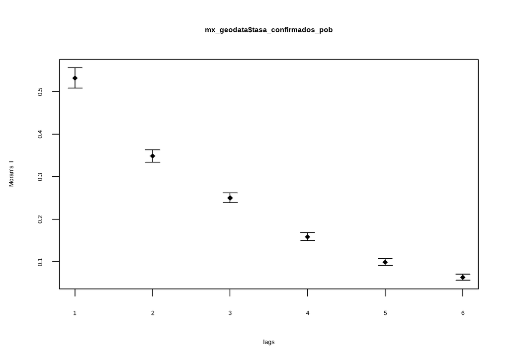

```r
# Computing Moran’s I correlogram
Moran_Correlogram <- sp.correlogram(swm_queen, mx_geodata$tasa_confirmados_pob, order = 6, method = "I", style = "B")
plot(Moran_Correlogram)
```

Con este correlograma, podemos observar que la autocorrelación espacial aumenta cuando la distancia entre vecinos es menor, lo que indica que los vecinos más cercanos experimentan una autocorrelación más fuerte. A medida que nos alejamos, la autocorrelación disminuye, lo que significa que la relación entre las observaciones se debilita a medida que la distancia aumenta.

## Especificar y estimar 1 modelo de regresión global (no espacial).

Construiremos un modelo lineal con variables que sabemos cuentan con significancia y ayudan a explicar el comportamiento de la tasa de confirmados en el país:

```r
# non- spatial regression results
df$region <- as.factor(df$region)
df$entidad <- as.factor(df$entidad)
df$tasa_hospitales <- (df$No_hospitales / df$poblacion_2022) * 10000
non_spatial_model = lm(tasa_confirmados_pob ~ gini2015 + inclusion_fin_2019 + tasa_hospitales + porcentaje_pob_acceso_ss + pop_hypertension + pop_diabetes, data = df)
summary(non_spatial_model)
```

```
##
## Call:
## lm(formula = tasa_confirmados_pob ~ gini2015 + inclusion_fin_2019 +
##     tasa_hospitales + porcentaje_pob_acceso_ss + pop_hypertension +
##     pop_diabetes, data = df)
##
## Residuals:
##     Min      1Q  Median      3Q     Max
## -350.47  -40.15  -10.67   21.53  902.86
##
## Coefficients:
##                           Estimate Std. Error t value Pr(>|t|)
## (Intercept)               179.6498    22.9439   7.830 7.23e-15 ***
## gini2015                  243.2598    47.6249   5.108 3.51e-07 ***
## inclusion_fin_2019       2624.4293   243.8370  10.763  < 2e-16 ***
## tasa_hospitales             1.3749     0.2378   5.781 8.38e-09 ***
## porcentaje_pob_acceso_ss -303.2435    12.9464 -23.423  < 2e-16 ***
## pop_hypertension           -1.9783     0.4927  -4.015 6.13e-05 ***
## pop_diabetes                4.2869     0.9084   4.719 2.50e-06 ***
## ---
## Signif. codes:  0 '***' 0.001 '**' 0.01 '*' 0.05 '.' 0.1 ' ' 1
##
## Residual standard error: 82.05 on 2430 degrees of freedom
## Multiple R-squared:  0.3766, Adjusted R-squared:  0.375
## F-statistic: 244.6 on 6 and 2430 DF,  p-value: < 2.2e-16
```

```r
AIC(non_spatial_model)
```

```
## [1] 28406.51
```

Podemos destacar que nuestro modelo es estadisticamente significativo y según la R2 ajustada, el 37.5% de la variación en la tasa de confirmados es explicada por el comportamiento de nuestras variables predictoras. No obstante, el AIC del modelo es muy alto, lo cual tomaremos en cuenta al momento de compararlo con el AIC de los modelos que toman en cuenta el factor espacial.

En cuanto a la interpretación de los resultados en el contexto estudiado:

- El intercepto es de 179.6498, lo que significa que cuando todas las variables explicativas son iguales a cero, la tasa de confirmados por cada 10,000 habitantes es de aproximadamente 180.
- El coeficiente para gini2015 es de 243.2598, lo que indica que un aumento de una unidad en el índice Gini (medida de la desigualdad económica de 2015) está asociado con un aumento de 243.2598 en la tasa de confirmados.
- El coeficiente para inclusion_fin_2019 es de 2624.4293, lo que significa que un aumento de una unidad en el índice de inclusión financiera de 2019 (medida del acceso a los servicios financieros) está asociado con un aumento de 2624.4293 en la tasa de confirmados.
- **El coeficiente para tasa_hospitales es de 1.3749, lo que indica que un aumento de una unidad en la tasa de hospitales por cada 10,000 habitantes está asociado con un aumento de 1.3749 en la tasa de confirmados.**
- **El coeficiente para porcentaje_pob_acceso_ss es de -303.2435, lo que significa que un aumento de una unidad en el porcentaje de la población con acceso a servicios de salud está asociado con una disminución de 303.2435 en la tasa de confirmados.**
- El coeficiente para pop_hypertension es de -1.9783, lo que indica que un aumento de una unidad en la proporción de la población con hipertensión está asociado con una disminución de 1.9783 en la tasa de confirmados. Este resultado nos resulta extraño, ya que esperaríamos que pasara lo contrario.
- El coeficiente para pop_diabetes es de 4.2869, lo que significa que un aumento de una unidad en la proporción de la población con diabetes está asociado con un aumento de 4.2869 en la tasa de confirmados por cada 10,000 habitantes.

## Especificar y estimar 2 modelos de regresión GWR. Considerar el uso de matrices de conectividad distintos para la especificación y estimación de cada modelo.

Para construir nuestro modelo de regresión espacial, es necesario preparar los datos, lo que implica convertirlos en factores cuando sea necesario y reemplazar los valores de 0 por 0.01 para evitar errores en el código. Además, evaluaremos la normalidad de los datos y los transformaremos, ya sea mediante la aplicación de una transformación logarítmica o cuadrática, para mejorar la normalidad y obtener resultados más precisos y con menor margen de error.

```r
# convert to sp
mx.sp = as(mx_shp, "Spatial")

mx_geodata$region <- as.factor(mx_geodata$region)
mx_geodata$tasa_hospitales <- (mx_geodata$No_hospitales / mx_geodata$poblacion_2022)*10000
mx_geodata$tasa_confirmados_pob[mx_geodata$tasa_confirmados_pob == 0] <- 0.01
mx_geodata$inclusion_fin_2019[mx_geodata$inclusion_fin_2019 == 0] <- 0.01
mx_geodata$inclusion_fin_2019[mx_geodata$inclusion_fin_2019 == 0] <- 0.01
summary(mx_geodata)
```

```
## Object of class SpatialPolygonsDataFrame
## Coordinates:
##         min       max
## x -118.4076 -86.71041
## y   14.5321  32.71865
## Is projected: FALSE
## proj4string : [+proj=longlat +datum=WGS84 +no_defs]
## Data attributes:
##    CODELAG             CVE_ENT         IDUNICO        IDUNICO.1
##  Length:2437        Min.   : 1.00   Min.   : 1001   Min.   : 1001
##  Class :character   1st Qu.:14.00   1st Qu.:14081   1st Qu.:14081
##  Mode  :character   Median :20.00   Median :20227   Median :20227
##                     Mean   :19.25   Mean   :19355   Mean   :19355
##                     3rd Qu.:24.00   3rd Qu.:24032   3rd Qu.:24032
##                     Max.   :32.00   Max.   :32058   Max.   :32058
##      mpio           poblacion_2022      hogrem2015      hogremjefmuj2015
##  Length:2437        Min.   :     95   Min.   :0.00000   Min.   :0.0000
##  Class :character   1st Qu.:   4566   1st Qu.:0.02286   1st Qu.:0.2214
##  Mode  :character   Median :  14240   Median :0.05316   Median :0.2606
##                     Mean   :  52375   Mean   :0.08564   Mean   :0.2586
##                     3rd Qu.:  37381   3rd Qu.:0.11998   3rd Qu.:0.2956
##                     Max.   :1815551   Max.   :0.52027   Max.   :0.4824
##  popnoafmed2015       gini2015        popden2020        crimen_2018
##  Min.   :0.01124   Min.   :0.3030   Min.   :    0.16   Min.   :  0.00
##  1st Qu.:0.09746   1st Qu.:0.3690   1st Qu.:   17.79   1st Qu.:  0.00
##  Median :0.13690   Median :0.3870   Median :   52.52   Median :  9.76
##  Mean   :0.14960   Mean   :0.3917   Mean   :  313.79   Mean   : 19.09
##  3rd Qu.:0.19274   3rd Qu.:0.4100   3rd Qu.:  143.98   3rd Qu.: 25.84
##  Max.   :0.62101   Max.   :0.6400   Max.   :56489.74   Max.   :719.42
##   crimen_2019     inclusion_fin_2019 porcentaje_pob_pobreza
##  Min.   :  0.00   Min.   :0.00130    Min.   :0.0545
##  1st Qu.:  0.00   1st Qu.:0.01000    1st Qu.:0.4549
##  Median : 11.54   Median :0.01000    Median :0.6250
##  Mean   : 20.40   Mean   :0.01109    Mean   :0.6183
##  3rd Qu.: 27.00   3rd Qu.:0.01000    3rd Qu.:0.8009
##  Max.   :551.82   Max.   :0.10680    Max.   :0.9965
##  porcentaje_pob_pobreza_ext porcentaje_pob_servicios_salud
##  Min.   :0.0000             Min.   :0.0105
##  1st Qu.:0.0535             1st Qu.:0.1609
##  Median :0.1243             Median :0.2325
```

[output cut: 37 more lines]

```
##  Max.   :56.04    Max.   :31.67   Max.   :98230.5   Max.   :4698.00
##    entidad                   region        densidad       tasa_confirmados_pob
##  Length:2437        Centro      : 579   Min.   :   95.0   Min.   :   0.01
##  Class :character   Centro Norte: 472   1st Qu.:  707.4   1st Qu.:  24.42
##  Mode  :character   Norte       : 274   Median : 1125.4   Median :  59.73
##                     Sur         :1112   Mean   : 1790.5   Mean   :  89.91
##                                         3rd Qu.: 1997.2   3rd Qu.: 118.73
##                                         Max.   :22658.5   Max.   :1151.25
##  tasa_confirmados_km sp_tasa_confirmados_pob tasa_hospitales
##  Min.   :   0.0000   Min.   :  1.372         Min.   :  0.4413
##  1st Qu.:   0.0606   1st Qu.: 41.273         1st Qu.:  5.0069
##  Median :   0.2481   Median : 74.726         Median :  8.8856
##  Mean   :   8.0781   Mean   : 93.112         Mean   : 10.6320
##  3rd Qu.:   1.0931   3rd Qu.:123.162         3rd Qu.: 14.1363
##  Max.   :1136.9697   Max.   :796.830         Max.   :105.2632
```

A continuación, presentamos un análisis de normalidad para cada variable y sus respectivas transformaciones, con el fin de identificar la mejor opción de transformación en cada caso:

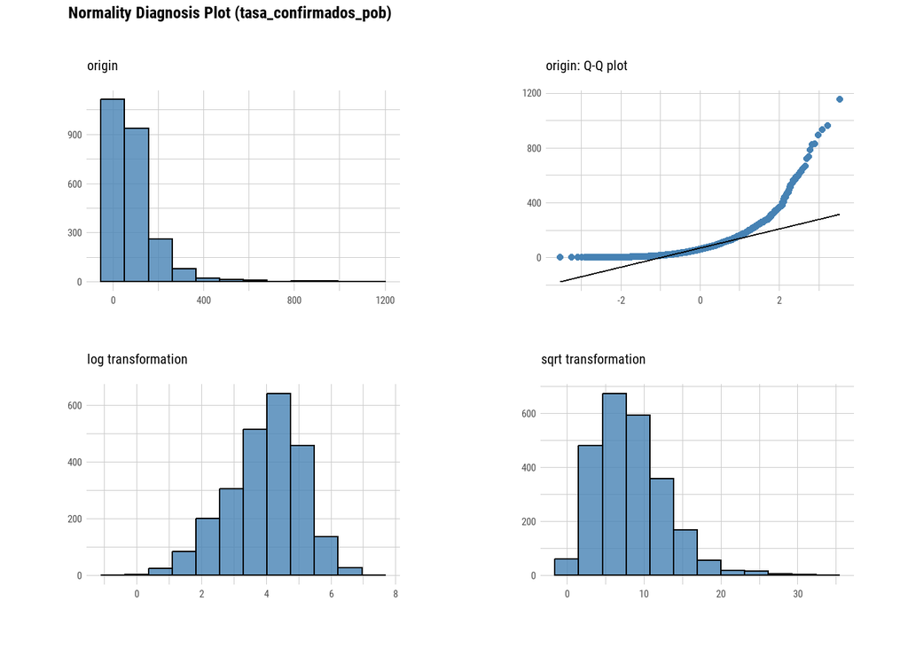

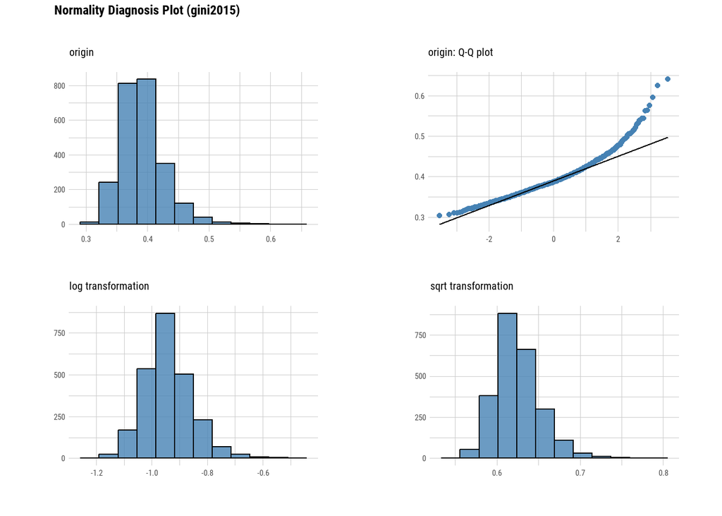

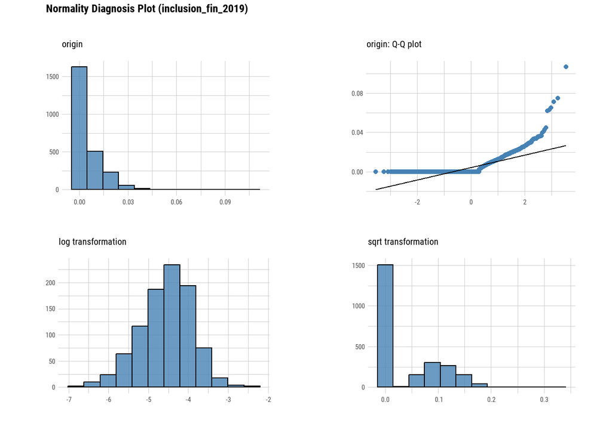

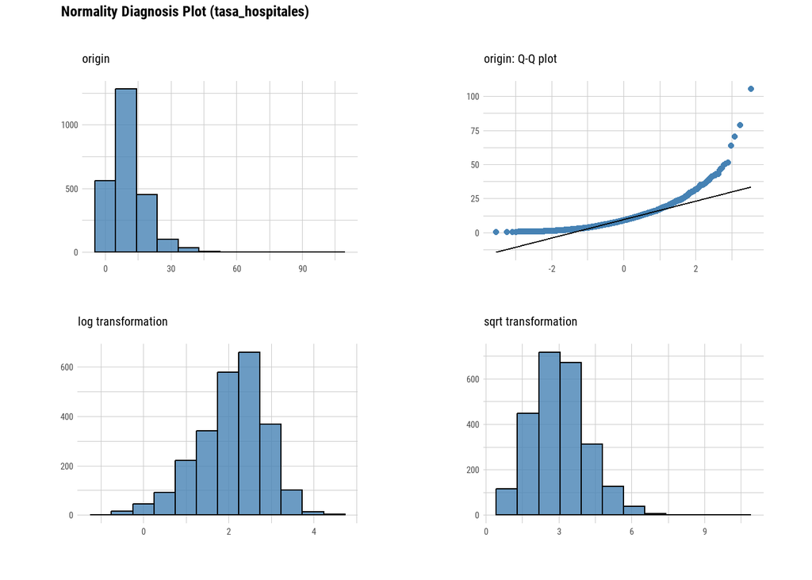

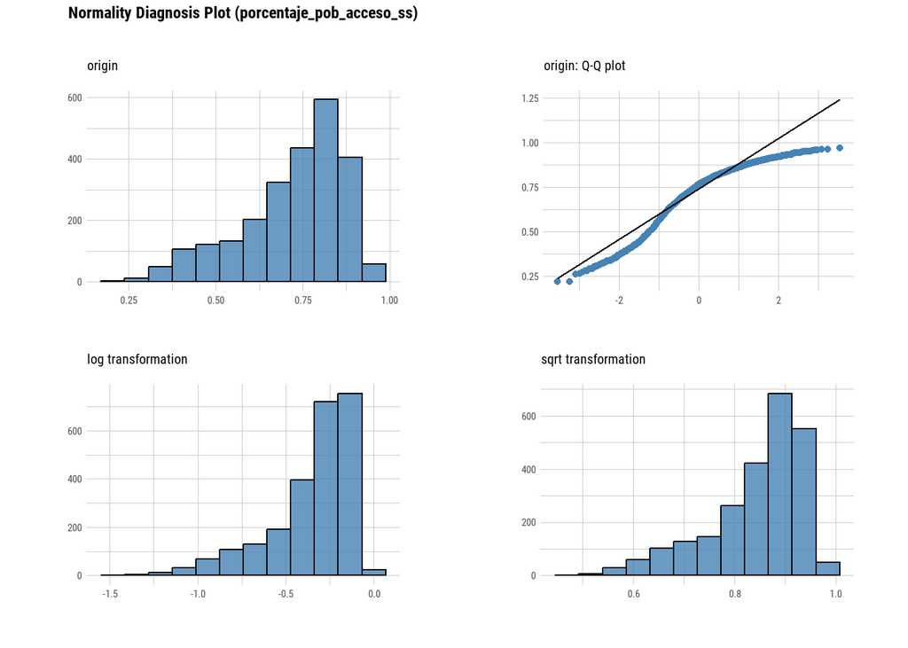

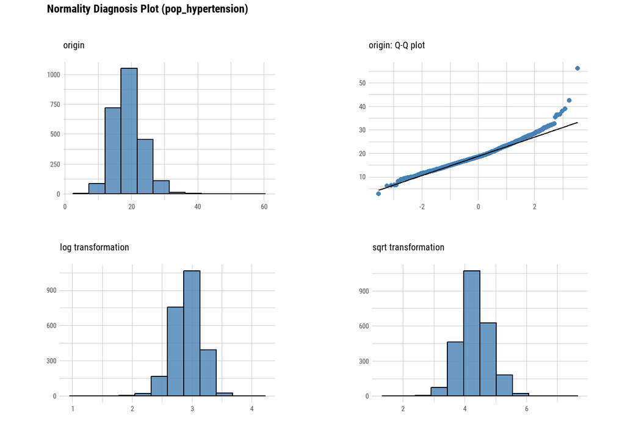

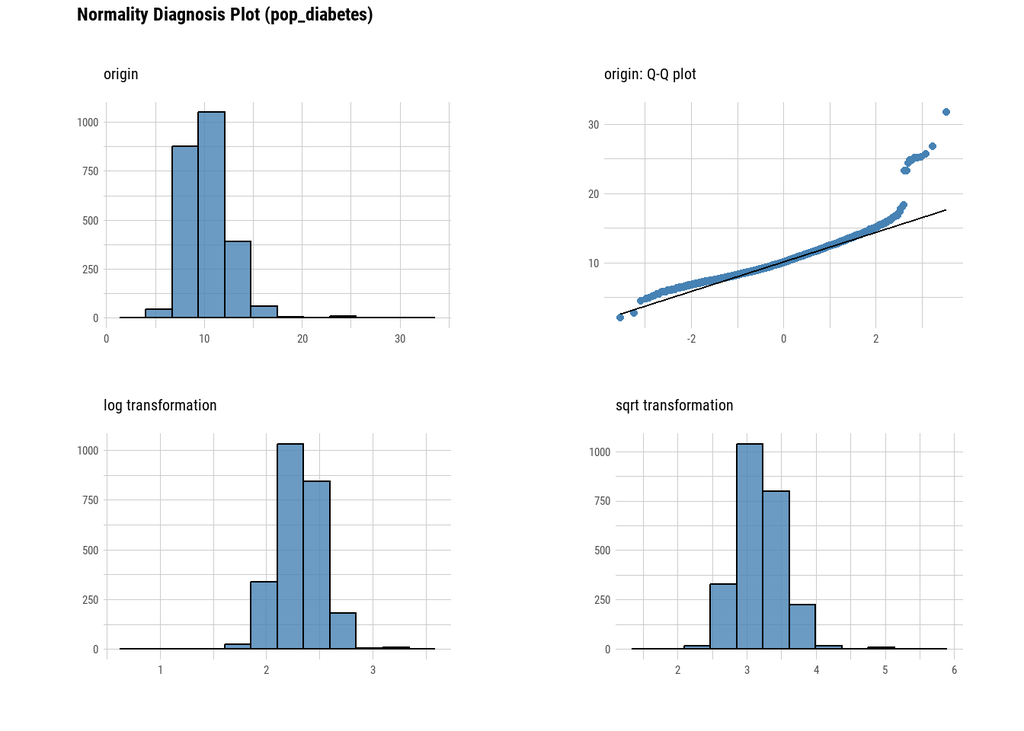

```r
plot_normality(df, tasa_confirmados_pob, gini2015, inclusion_fin_2019, tasa_hospitales, porcentaje_pob_acceso_ss, pop_hypertension, pop_diabetes)
```

Con todo, construiremos dos modelos de regresión georgráfica ponderada y como criterio de selección tomaremos en cuenta el AIC:

```r
bw1 <- bw.gwr(log(tasa_confirmados_pob) ~ log(gini2015) + log(inclusion_fin_2019) + log(tasa_hospitales) + porcentaje_pob_acceso_ss + sqrt(pop_hypertension) + sqrt(pop_diabetes),
             approach = "AIC", adaptive = T, data=mx_geodata)
```

```
## Take a cup of tea and have a break, it will take a few minutes.
##           -----A kind suggestion from GWmodel development group
## Adaptive bandwidth (number of nearest neighbours): 1513 AICc value: 8250.123
## Adaptive bandwidth (number of nearest neighbours): 943 AICc value: 8093.66
## Adaptive bandwidth (number of nearest neighbours): 589 AICc value: 8010.802
## Adaptive bandwidth (number of nearest neighbours): 372 AICc value: 7928.618
## Adaptive bandwidth (number of nearest neighbours): 236 AICc value: 7879.419
## Adaptive bandwidth (number of nearest neighbours): 154 AICc value: 7859.222
## Adaptive bandwidth (number of nearest neighbours): 101 AICc value: 7916.917
## Adaptive bandwidth (number of nearest neighbours): 184 AICc value: 7863.737
## Adaptive bandwidth (number of nearest neighbours): 132 AICc value: 7867.448
## Adaptive bandwidth (number of nearest neighbours): 164 AICc value: 7859.346
## Adaptive bandwidth (number of nearest neighbours): 144 AICc value: 7862.114
## Adaptive bandwidth (number of nearest neighbours): 156 AICc value: 7858.346
## Adaptive bandwidth (number of nearest neighbours): 162 AICc value: 7858.881
## Adaptive bandwidth (number of nearest neighbours): 157 AICc value: 7858.102
## Adaptive bandwidth (number of nearest neighbours): 153 AICc value: 7859.143
## Adaptive bandwidth (number of nearest neighbours): 155 AICc value: 7859.221
## Adaptive bandwidth (number of nearest neighbours): 153 AICc value: 7859.143
## Adaptive bandwidth (number of nearest neighbours): 154 AICc value: 7859.222
## Adaptive bandwidth (number of nearest neighbours): 153 AICc value: 7859.143
## Adaptive bandwidth (number of nearest neighbours): 153 AICc value: 7859.143
## Adaptive bandwidth (number of nearest neighbours): 152 AICc value: 7858.839
## Adaptive bandwidth (number of nearest neighbours): 152 AICc value: 7858.839
## Adaptive bandwidth (number of nearest neighbours): 151 AICc value: 7859.153
## Adaptive bandwidth (number of nearest neighbours): 151 AICc value: 7859.153
## Adaptive bandwidth (number of nearest neighbours): 150 AICc value: 7858.888
## Adaptive bandwidth (number of nearest neighbours): 150 AICc value: 7858.888
## Adaptive bandwidth (number of nearest neighbours): 149 AICc value: 7859.792
## Adaptive bandwidth (number of nearest neighbours): 149 AICc value: 7859.792
## Adaptive bandwidth (number of nearest neighbours): 148 AICc value: 7860.085
## Adaptive bandwidth (number of nearest neighbours): 148 AICc value: 7860.085
## Adaptive bandwidth (number of nearest neighbours): 147 AICc value: 7860.469
## Adaptive bandwidth (number of nearest neighbours): 147 AICc value: 7860.469
## Adaptive bandwidth (number of nearest neighbours): 146 AICc value: 7861.011
## Adaptive bandwidth (number of nearest neighbours): 146 AICc value: 7861.011
## Adaptive bandwidth (number of nearest neighbours): 145 AICc value: 7862.375
## Adaptive bandwidth (number of nearest neighbours): 145 AICc value: 7862.375
## Adaptive bandwidth (number of nearest neighbours): 144 AICc value: 7862.114
```

```r
# determine the kernel bandwidth
bw2 <- bw.gwr(log(tasa_confirmados_pob) ~ log(gini2015) + log(inclusion_fin_2019) + log(tasa_hospitales) + porcentaje_pob_acceso_ss + sqrt(pop_hypertension) + sqrt(pop_diabetes),
              approach = "AIC", adaptive = F, data = mx_geodata)
```

```
## Take a cup of tea and have a break, it will take a few minutes.
##           -----A kind suggestion from GWmodel development group
## Fixed bandwidth: 19.92188 AICc value: 8498.177
## Fixed bandwidth: 12.31486 AICc value: 8452.462
## Fixed bandwidth: 7.613466 AICc value: 8332.121
## Fixed bandwidth: 4.707843 AICc value: 8243.333
## Fixed bandwidth: 2.912069 AICc value: 8766.849
## Fixed bandwidth: 5.817693 AICc value: 8274.127
## Fixed bandwidth: 4.021919 AICc value: 8230.507
## Fixed bandwidth: 3.597994 AICc value: 8278.916
## Fixed bandwidth: 4.283919 AICc value: 8234.555
## Fixed bandwidth: 3.859994 AICc value: 8228.39
## Fixed bandwidth: 3.759919 AICc value: 8227.31
## Fixed bandwidth: 3.698069 AICc value: 8226.752
## Fixed bandwidth: 3.659844 AICc value: 9397.864
## Fixed bandwidth: 3.721693 AICc value: 8226.955
## Fixed bandwidth: 3.683468 AICc value: 8226.633
## Fixed bandwidth: 3.674444 AICc value: 8226.562
## Fixed bandwidth: 3.668867 AICc value: 8227.937
## Fixed bandwidth: 3.677891 AICc value: 8226.589
## Fixed bandwidth: 3.672314 AICc value: 8226.545
## Fixed bandwidth: 3.670998 AICc value: 8226.535
## Fixed bandwidth: 3.670184 AICc value: 8226.529
## Fixed bandwidth: 3.669681 AICc value: 8226.525
## Fixed bandwidth: 3.66937 AICc value: 8235.947
## Fixed bandwidth: 3.669873 AICc value: 8226.526
## Fixed bandwidth: 3.669562 AICc value: 8238.958
## Fixed bandwidth: 3.669754 AICc value: 8226.525
## Fixed bandwidth: 3.669636 AICc value: 8236.802
## Fixed bandwidth: 3.669709 AICc value: 8226.525
```

Con ambos resultados, la estimación del modelo utilizando el enfoque de banda adaptativo es el modelo con el menor AIC, por lo que utilizaremos ese modelo para el ajuste de nuestro modelo final:

```r
# fit the GWR model
m.gwr <- gwr.basic(log(tasa_confirmados_pob) ~ log(gini2015) + log(inclusion_fin_2019) + log(tasa_hospitales) + porcentaje_pob_acceso_ss + sqrt(pop_hypertension) + sqrt(pop_diabetes), adaptive = T, data = mx_geodata, bw = bw1)
m.gwr
```

```
##    *                       Package   GWmodel                             *
##    Program starts at: 2023-05-03 13:52:11
##    Call:
##    gwr.basic(formula = log(tasa_confirmados_pob) ~ log(gini2015) +
##     log(inclusion_fin_2019) + log(tasa_hospitales) + porcentaje_pob_acceso_ss +
##     sqrt(pop_hypertension) + sqrt(pop_diabetes), data = mx_geodata,
##     bw = bw1, adaptive = T)
##
##    Dependent (y) variable:  tasa_confirmados_pob
##    Independent variables:  gini2015 inclusion_fin_2019 tasa_hospitales porcentaje_pob_acceso_ss pop_hypertension pop_diabetes
##    Number of data points: 2437
##    *                    Results of Global Regression                     *
##
##    Call:
##     lm(formula = formula, data = data)
##
##    Residuals:
##      Min       1Q   Median       3Q      Max
## -10.5595  -0.3972   0.1746   0.7031   2.7983
##
##    Coefficients:
##                             Estimate Std. Error t value Pr(>|t|)
##    (Intercept)               8.55430    0.60160  14.219  < 2e-16 ***
##    log(gini2015)             2.46943    0.32608   7.573 5.15e-14 ***
##    log(inclusion_fin_2019)   0.09253    0.07412   1.248    0.212
##    log(tasa_hospitales)      0.24042    0.03961   6.069 1.49e-09 ***
##    porcentaje_pob_acceso_ss -4.26032    0.21268 -20.032  < 2e-16 ***
##    sqrt(pop_hypertension)   -0.33287    0.07417  -4.488 7.52e-06 ***
##    sqrt(pop_diabetes)        0.63559    0.10481   6.064 1.53e-09 ***
##
##    ---Significance stars
##    Signif. codes:  0 '***' 0.001 '**' 0.01 '*' 0.05 '.' 0.1 ' ' 1
##    Residual standard error: 1.396 on 2430 degrees of freedom
##    Multiple R-squared: 0.2352
##    Adjusted R-squared: 0.2333
##    F-statistic: 124.5 on 6 and 2430 DF,  p-value: < 2.2e-16
##    ***Extra Diagnostic information
##    Residual sum of squares: 4735.13
##    Sigma(hat): 1.394493
##    AIC:  8550.663
```

[output cut: 24 more lines]

```
##    porcentaje_pob_acceso_ss  4.5510
##    sqrt(pop_hypertension)    1.9593
##    sqrt(pop_diabetes)        2.4379
##    ************************Diagnostic information*************************
##    Number of data points: 2437
##    Effective number of parameters (2trace(S) - trace(S'S)): 346.4038
##    Effective degrees of freedom (n-2trace(S) + trace(S'S)): 2090.596
##    AICc (GWR book, Fotheringham, et al. 2002, p. 61, eq 2.33): 7858.102
##    AIC (GWR book, Fotheringham, et al. 2002,GWR p. 96, eq. 4.22): 7530.335
##    BIC (GWR book, Fotheringham, et al. 2002,GWR p. 61, eq. 2.34): 6873.932
##    Residual sum of squares: 2816.291
##    R-square value:  0.545102
##    Adjusted R-square value:  0.4696911
##
##    Program stops at: 2023-05-03 13:52:12
```

El modelo se ajustó a las 2,437 observaciones de nuestro dataset. La variable dependiente es log(tasa_confirmados_pob), que es el logaritmo natural de la tasa de confirmados por cada 10,000 habitantes. Las variables independientes son log(gini2015), log(inclusion_fin_2019), log(tasa_hospitales), porcentaje_pob_acceso_ss, sqrt(pop_hypertension) y sqrt(pop_diabetes), que representan el logaritmo de la medida de la desigualdad económica de 2015, el logaritmo del índice de inclusión financiera de 2019, el logaritmo de la tasa de hospitales por cada 10,000 habitantes, el porcentaje de la población con acceso a servicios de seguridad social, la raíz cuadrada de la proporción de población con hipertensión y la raíz cuadrada de la proporción de población con diabetes, respectivamente.

Los resultados de la regresión global muestran que todas la variables independientes, excepto log(inclusion_fin_2019), son estadísticamente significativas. La R2 ajustada es de 0.2333, lo que significa que las variables independientes explican el 23% en la variación en la tasa de confirmados de COVID-19 por cada 10,000 habitantes. El AIC es igual a 8550.663.

Ahora bien, también se presentan los resultados del modelo GWR. Este modelo estima un conjunto de coeficientes para cada observación, lo que permite que la relación entre las variables dependientes e independientes varíe en el espacio. El resumen de los coeficientes estimados por GWR muestra que estos varían en el espacio, y los rangos de los coeficientes difieren de los del modelo de regresión global.

Para cada variable independiente, el resumen muestra el valor mínimo, primer cuartil, mediana, tercer cuartil y valor máximo de los coeficientes estimados en todas las ubicaciones geográficas. Los valores de los coeficientes estimados pueden variar en diferentes ubicaciones geográficas, como se indica por los diferentes rangos de los coeficientes estimados.

Los valores de los coeficientes indican la magnitud y dirección de la relación entre la variable independiente y la variable dependiente. Un coeficiente positivo indica que un aumento en la variable independiente está asociado con un aumento en la variable dependiente, mientras que un coeficiente negativo indica que un aumento en la variable independiente está asociado con una disminución en la variable dependiente.

La R2 ajustada del modelo GWR es de 0.4696911, lo que significa que las variables independientes explican el 47% en la variación en la tasa de confirmados de COVID-19 por cada 10,000 habitantes. El AIC es igual a 7530.335, que es menor al modelo global, por lo que nuestro modelo de regresión geografica ponderada es un muy buen modelo y se puede utilizar para explicar el comportamiento de los casos de COVID-19 en los municipios de México.

## Considerando el criterio de AIC seleccionar el modelo de regresión que muestre un mejor desempeño

El mejor modelo en este caso es el modelo de enfoque de banda adaptativo, ya que tiene el valor AIC más bajo, por lo que consideraremos este modelo para evaluar resultados y analizar el comportamiento de los datos.

En este espacio se presentan los resultados de nuestro modelo en distintas ubicaciones, incluyendo información sobre la variable dependiente, las variables explicativas, los residuos, los coeficientes del modelo en cada región y las estadísticas de ajuste correspondientes:

```r
# Mapping GWR outputs
gwr_sf = st_as_sf(m.gwr$SDF)
gwr_sf
```

```
## Simple feature collection with 2437 features and 27 fields
## Geometry type: MULTIPOLYGON
## Dimension:     XY
## Bounding box:  xmin: -118.4076 ymin: 14.5321 xmax: -86.71041 ymax: 32.71865
## Geodetic CRS:  WGS 84
## First 10 features:
##   Intercept log(gini2015) log(inclusion_fin_2019) log(tasa_hospitales)
## 0  5.802900      1.214059             0.080904420            0.2601184
## 1  6.470397      1.992523            -0.008593137            0.3223551
## 2  5.206423      1.431818             0.109712335            0.1633590
## 3  5.690727      2.824458             0.049245214            0.1609315
## 4  5.484120      2.503719             0.036123320            0.1677487
## 5  5.680612      2.809424             0.029570044            0.1679617
## 6  4.975101      1.899645             0.089218045            0.1297407
## 7  6.175017      3.245573             0.016896911            0.1949870
```

[output cut: 79 more lines]

```r
summary(gwr_sf)
```

```
##    Intercept      log(gini2015)     log(inclusion_fin_2019)
##  Min.   :-6.928   Min.   :-7.4983   Min.   :-1.415040
##  1st Qu.: 5.679   1st Qu.: 0.4977   1st Qu.: 0.005151
##  Median : 7.341   Median : 1.1815   Median : 0.142329
##  Mean   : 9.007   Mean   : 1.6616   Mean   : 0.325012
##  3rd Qu.:11.299   3rd Qu.: 2.6061   3rd Qu.: 0.305603
##  Max.   :31.120   Max.   :12.1625   Max.   : 5.362703
##  log(tasa_hospitales) porcentaje_pob_acceso_ss sqrt(pop_hypertension)
##  Min.   :-0.6643      Min.   :-12.312          Min.   :-2.08766
##  1st Qu.: 0.1402      1st Qu.: -4.628          1st Qu.:-0.40491
##  Median : 0.2226      Median : -2.747          Median :-0.11625
##  Mean   : 0.1936      Mean   : -3.031          Mean   :-0.14672
##  3rd Qu.: 0.3020      3rd Qu.: -1.699          3rd Qu.: 0.09303
##  Max.   : 0.9946      Max.   :  4.551          Max.   : 1.95933
##  sqrt(pop_diabetes)       y               yhat           residual
##  Min.   :-4.6880    Min.   :-4.605   Min.   :-1.933   Min.   :-7.860268
##  1st Qu.:-0.1006    1st Qu.: 3.195   1st Qu.: 3.064   1st Qu.:-0.305880
##  Median : 0.1484    Median : 4.090   Median : 4.009   Median : 0.071787
##  Mean   : 0.1121    Mean   : 3.818   Mean   : 3.815   Mean   : 0.002535
##  3rd Qu.: 0.5411    3rd Qu.: 4.777   3rd Qu.: 4.617   3rd Qu.: 0.443362
##  Max.   : 2.4379    Max.   : 7.049   Max.   : 6.869   Max.   : 4.617707
##     CV_Score Stud_residual        Intercept_SE   log(gini2015)_SE
##  Min.   :0   Min.   :-7.100448   Min.   :2.091   Min.   :0.9376
##  1st Qu.:0   1st Qu.:-0.292508   1st Qu.:2.762   1st Qu.:1.5052
##  Median :0   Median : 0.066191   Median :3.329   Median :1.7081
##  Mean   :0   Mean   : 0.001027   Mean   :3.307   Mean   :1.7431
##  3rd Qu.:0   3rd Qu.: 0.415534   3rd Qu.:3.752   3rd Qu.:2.0058
##  Max.   :0   Max.   : 5.179770   Max.   :6.667   Max.   :2.7804
##  log(inclusion_fin_2019)_SE log(tasa_hospitales)_SE porcentaje_pob_acceso_ss_SE
##  Min.   :0.2005             Min.   :0.1477          Min.   :0.7054
##  1st Qu.:0.2987             1st Qu.:0.1829          1st Qu.:1.0138
##  Median :0.3402             Median :0.1976          Median :1.2228
##  Mean   :0.4112             Mean   :0.2090          Mean   :1.2320
##  3rd Qu.:0.4546             3rd Qu.:0.2254          3rd Qu.:1.4268
##  Max.   :1.5113             Max.   :0.3571          Max.   :2.7570
##  sqrt(pop_hypertension)_SE sqrt(pop_diabetes)_SE  Intercept_TV
##  Min.   :0.2340            Min.   :0.2611        Min.   :-2.494
##  1st Qu.:0.3817            1st Qu.:0.4699        1st Qu.: 1.716
##  Median :0.4388            Median :0.5819        Median : 2.439
##  Mean   :0.4326            Mean   :0.5652        Mean   : 2.680
```

[output cut: 8 more lines]

```
##  Max.   : 6.9218   Max.   : 5.06936           Max.   : 4.0408
##  porcentaje_pob_acceso_ss_TV sqrt(pop_hypertension)_TV sqrt(pop_diabetes)_TV
##  Min.   :-7.990              Min.   :-4.0602           Min.   :-7.3889
##  1st Qu.:-3.362              1st Qu.:-0.9097           1st Qu.:-0.2019
##  Median :-2.527              Median :-0.2668           Median : 0.2898
##  Mean   :-2.470              Mean   :-0.3515           Mean   : 0.2410
##  3rd Qu.:-1.639              3rd Qu.: 0.2040           3rd Qu.: 0.9667
##  Max.   : 3.198              Max.   : 4.0918           Max.   : 5.2853
##     Local_R2               geometry
##  Min.   :0.2396   MULTIPOLYGON :2437
##  1st Qu.:0.5522   epsg:4326    :   0
##  Median :0.6908   +proj=long...:   0
##  Mean   :0.6513
##  3rd Qu.:0.7724
##  Max.   :0.9357
```

## Interpretar y visualizar en 5-6 mapas los principales hallazgos de los resultados obtenidos a partir del modelo de regresión seleccionado (por ejemplo, mapeo de predicción de principal variable de interés, significancia estadística de variables explicativas, R2).

```r
# local prediction of dependent variable
gwr_sf$y_predicted <- exp(gwr_sf$yhat)
#mapview(gwr_sf, zcol="y_predicted")
```

```r
 # local prediction of statistically significant explanatory variables
#mapview(gwr_sf, zcol= 'log(gini2015)')
#mapview(gwr_sf, zcol= 'log(inclusion_fin_2019)')
#mapview(gwr_sf, zcol= 'log(tasa_hospitales)')
#mapview(gwr_sf, zcol= 'porcentaje_pob_acceso_ss')
#mapview(gwr_sf, zcol= 'sqrt(pop_hypertension)')
#mapview(gwr_sf, zcol= 'sqrt(pop_diabetes)')
```

```r
# local prediction of R2
#mapview(gwr_sf, zcol="Local_R2")
```

Finalmente, podemos ver la variación de la significancia de algunas variables en cada región del país:

[figure not shown]

```r
# visualizing more than 2 explanatory variables
map_1 <- tm_shape(gwr_sf) +
  tm_polygons(col = "log(tasa_hospitales)_TV", style = "quantile", palette = "BuGn", title = "P-Value of tasa_hospitales")
map_2 <- tm_shape(gwr_sf) +
  tm_polygons(col = "sqrt(pop_hypertension)_TV", style = "quantile", palette = "-BuGn", title = "P-Value of op_hypertension")
tmap_arrange(map_1, map_2, ncol = 2)
```

## A partir de los modelos de regresión seleccionados y los hallazgos identificados describir 2-3 sugerencias relacionadas con la toma de decisiones para el crecimiento / expansión territorial de organizaciones orientadas a las prestación de servicios de salud.

```r
### main insights are based on local results.

# table of GWR coefficients
gwr_table = apply(m.gwr$SDF@data[, 1:7], 2, summary)
# OLS coefficients
non_spatial_model_table = coef(non_spatial_model)
# joint together with a row bind
table <- rbind(gwr_table, non_spatial_model_table)
# add name to last row of tab
rownames(table)[7] <- "Global"
# transpose tab
table <- t(round(table, 3))
table
```

```
##                             Min. 1st Qu. Median   Mean 3rd Qu.   Max.   Global
## Intercept                 -6.928   5.679  7.341  9.007  11.299 31.120  179.650
## log(gini2015)             -7.498   0.498  1.182  1.662   2.606 12.162  243.260
## log(inclusion_fin_2019)   -1.415   0.005  0.142  0.325   0.306  5.363 2624.429
## log(tasa_hospitales)      -0.664   0.140  0.223  0.194   0.302  0.995    1.375
## porcentaje_pob_acceso_ss -12.312  -4.628 -2.747 -3.031  -1.699  4.551 -303.244
## sqrt(pop_hypertension)    -2.088  -0.405 -0.116 -0.147   0.093  1.959   -1.978
## sqrt(pop_diabetes)        -4.688  -0.101  0.148  0.112   0.541  2.438    4.287
```